# FIA NLS Models: Biomass vs. Stand Age (Temporally-Balanced dataset) – with Biomass Partitioning for the Eastern US

### model selection 2

```
## Analysis of Variance Table
##
## Model 1: B_plt_t2_MgHa ~ (1 + (MEASTIME_t2 - 1990) * tau/100) * (1 - alpha * B_L_prop) * A * STDAGE_t2/(k + STDAGE_t2)
## Model 2: B_plt_t2_MgHa ~ (1 + (MEASTIME_t2 - 1990) * tau/100) * (1 - alpha * B_L_prop) * (p * A + ((1 - p) * A * STDAGE_t2/(k + STDAGE_t2)))
## Model 3: B_plt_t2_MgHa ~ (1 + (MEASTIME_t2 - 1990) * tau/100) * (1 - alpha * B_L_prop) * (A * STDAGE_t2^s/(k^s + STDAGE_t2^s))
## Model 4: B_plt_t2_MgHa ~ (1 + (MEASTIME_t2 - 1990) * tau/100) * (1 - alpha * B_L_prop) * (p * A + ((1 - p) * A * STDAGE_t2^s/(k^s + STDAGE_t2^s)))
##   Res.Df Res.Sum Sq Df   Sum Sq F value Pr(>F)
## 1    298     113.37
## 2    297     113.26  1 0.115630  0.3032 0.5823
## 3    297     113.00  0 0.000000
## 4    296     112.91  1 0.094618  0.2480 0.6188
##   model      AIC
## 1     2 2987.903
## 2    2a 2989.595
## 3    2b 2988.916
## 4    2c 2990.663
```

```
##
## Formula: B_plt_t2_MgHa ~ (1 + (MEASTIME_t2 - 1990) * tau/100) * (1 - alpha *
##     B_L_prop) * A * STDAGE_t2/(k + STDAGE_t2)
##
## Parameters:
##       Estimate Std. Error t value Pr(>|t|)
## tau    0.07662    0.66159   0.116  0.90788
## alpha  0.77829    0.12977   5.998 5.79e-09 ***
## A     99.54181   19.23214   5.176 4.18e-07 ***
## k     53.05797   17.65911   3.005  0.00289 **
## ---
## Signif. codes:  0 '***' 0.001 '**' 0.01 '*' 0.05 '.' 0.1 ' ' 1
##
## Residual standard error: 0.6168 on 298 degrees of freedom
##
## Number of iterations to convergence: 5
## Achieved convergence tolerance: 6.942e-06
##   (4 observations deleted due to missingness)
```

### summary

- add p model: fits
- add s model: fits
- add s+p model: fits

### model selection 3

```
## Analysis of Variance Table
##
## Model 1: B_plt_t2_MgHa ~ (1 + (MEASTIME_t2 - 1990) * tau/100) * (a + b * exp(-((log(STDAGE_t2/c))/d)^2))
## Model 2: B_plt_t2_MgHa ~ (1 + (MEASTIME_t2 - 1990) * tau/100) * (1 - alpha * B_L_prop) * (a + b * exp(-((log(STDAGE_t2/c))/d)^2))
##   Res.Df Res.Sum Sq Df Sum Sq F value    Pr(>F)
## 1    297     124.07
## 2    296     113.29  1 10.775  28.151 2.203e-07 ***
## ---
## Signif. codes:  0 '***' 0.001 '**' 0.01 '*' 0.05 '.' 0.1 ' ' 1
##   model      AIC
## 1     2 2987.903
## 2     4 3017.126
## 3     5 2991.690
```

```
##
## Formula: B_plt_t2_MgHa ~ (1 + (MEASTIME_t2 - 1990) * tau/100) * (1 - alpha *
##     B_L_prop) * A * STDAGE_t2/(k + STDAGE_t2)
##
## Parameters:
##       Estimate Std. Error t value Pr(>|t|)
## tau    0.07662    0.66159   0.116  0.90788
## alpha  0.77829    0.12977   5.998 5.79e-09 ***
## A     99.54181   19.23214   5.176 4.18e-07 ***
## k     53.05797   17.65911   3.005  0.00289 **
## ---
## Signif. codes:  0 '***' 0.001 '**' 0.01 '*' 0.05 '.' 0.1 ' ' 1
##
## Residual standard error: 0.6168 on 298 degrees of freedom
##
## Number of iterations to convergence: 5
## Achieved convergence tolerance: 6.942e-06
##   (4 observations deleted due to missingness)
```

#### summary

- simple log-normal model: fits
- log-normal phi model: fits

### predict and plot

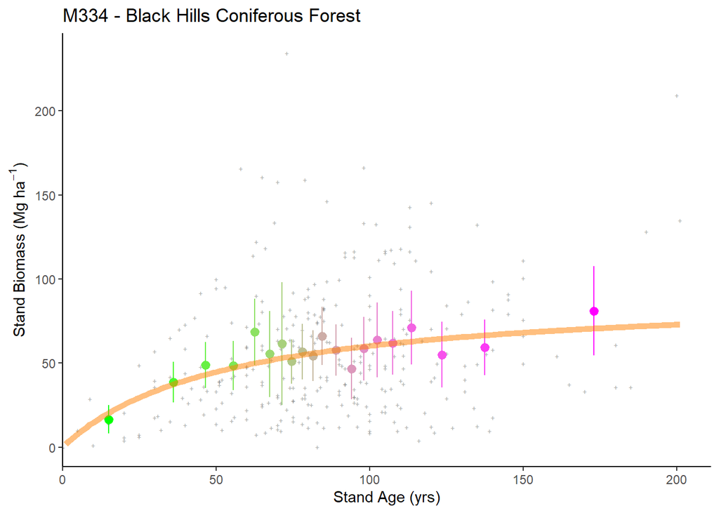

### plotting 2

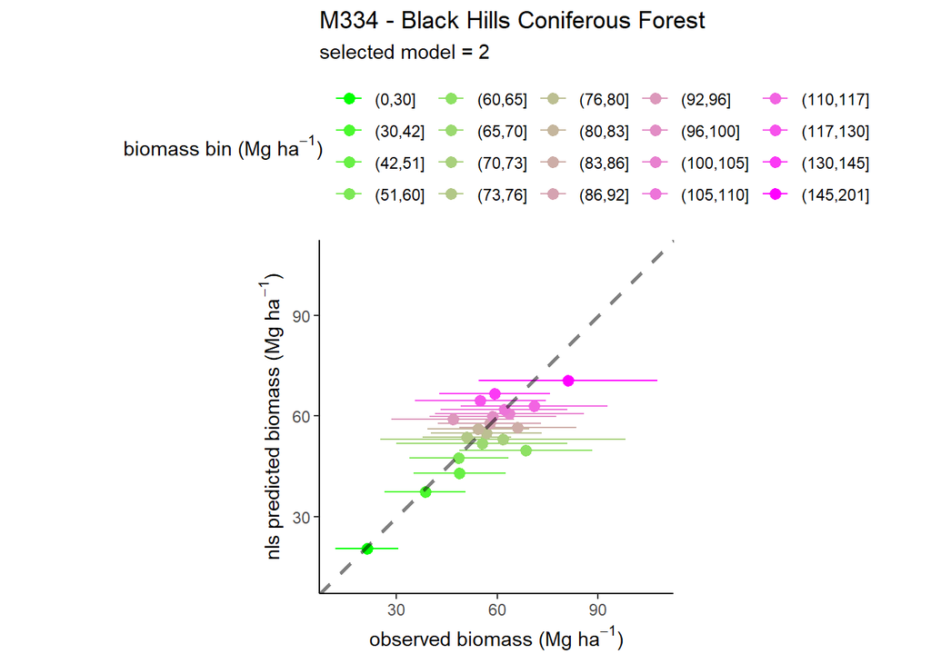

## M341 - Nevada-Utah Mountains Semi-Desert - Coniferous Forest - Alpine Meadow

### model selection 1

#### summary

- simple model: does not fit
- alpha model: does not fit

### model selection 2

### summary

- add p model: does not fit
- add s model: does not fit
- add s+p model: does not fit

### model selection 3

#### summary

- simple log-normal model: does not fit
- log-normal phi model: does not fit

### predict and plot

```
## [1] "cannot plot data with prediction"
```

### plotting 2

## Fitted parameters

### Best / selected models by ecoprovince

| Ecoprovince | Ecoregion | Sel.Mod.2 | Sel.Mod.3 | Best.Mod |
| --- | --- | --- | --- | --- |
| 211 | Northeastern Mixed Forest | 2 | 5 | 5 |
| 212 | Laurentian Mixed Forest | 2a | 5 | 5 |
| 221 | Eastern Broadleaf Forest | 2b | 5 | 5 |
| 222 | Midwest Broadleaf Forest | 2a | 5 | 5 |
| 223 | Central Interior Broadleaf Forest | 2c | 5 | 5 |
| 231 | Southeastern Mixed Forest | 2c | 5 | 5 |
| 232 | Outer Coastal Plain Mixed Forest | 2a | 5 | 5 |
| 234 | Lower Mississippi Riverine Forest | 2c | 5 | 5 |
| 242 | Pacific Lowland Mixed Forest | NA | NA | NA |
| 251 | Prairie Parkland (Temperate) | 2b | 5 | 5 |
| 255 | Prairie Parkland (Subtropical) | 2 | 5 | 5 |
| 261 | California Coastal Chaparral Forest and Shrub | NA | NA | NA |
| 262 | California Dry Steppe | NA | NA | NA |
| 263 | California Coastal Steppe - Mixed Forest and Redwood Forest | NA | NA | NA |
| 313 | Colorado Plateau Semi-Desert | NA | NA | NA |
| 315 | Southwest Plateau and Plains Dry Steppe and Shrub | NA | NA | NA |
| 321 | Chihuahuan Semi-Desert | NA | NA | NA |
| 322 | American Semidesert and Desert | NA | NA | NA |
| 331 | Great Plains/Palouse Dry Steppe | NA | NA | NA |
| 332 | Great Plains Steppe | 2 | 2 | 2 |
| 341 | Intermountain Semi-Desert and Desert | NA | NA | NA |
| 342 | Intermountain Semi-Desert | NA | NA | NA |
| 411 | Everglades | NA | NA | NA |
| M211 | Adirondack-New England Mixed forest - Coniferous Forest - Alpine Meadow | 2a | 5 | 5 |
| M221 | Central Appalachian Broadleaf Forest - Coniferous Forest - Meadow | 2c | 5 | 5 |
| M223 | Ozark Broadleaf Forest Meadow | 2 | 2 | 2 |
| M231 | Ouachita Mixed Forest | 2 | 2 | 2 |
| M242 | Cascade Mixed Forest | NA | NA | NA |
| M261 | Sierran Steppe - Mixed Forest - Coniferous Forest - Alpine Meadow | 2b | 2b | 2b |
| M262 | California Coastal Range Coniferous Forest - Open Woodland - Shrub - Meadow | NA | NA | NA |
| M313 | Arizona-New Mexico Mountains Semi-Desert - Open Woodland - Coniferous Forest - Alpine Meadow | NA | NA | NA |
| M331 | Southern Rocky Mountain Steppe - Open Woodland - Coniferous Forest - Alpine Meadow | NA | NA | NA |
| M332 | Middle Rocky Mountain Steppe - Coniferous Forest - Alpine Meadow | NA | NA | NA |
| M333 | Northern Rocky Mountain Steppe - Coniferous Forest - Alpine Meadow | NA | NA | NA |
| M334 | Black Hills Coniferous Forest | 2 | 2 | 2 |
| M341 | Nevada-Utah Mountains Semi-Desert - Coniferous Forest - Alpine Meadow | NA | NA | NA |

### table by ecoprovince

| Ecoprovince | Ecoregion | region | n.obs | n.plots | tau | tau.variance | tau.2.5 | tau.97.5 | alpha | alpha.variance | alpha.2.5 | alpha.97.5 | A | A.2.5 | A.97.5 | k | k.2.5 | k.97.5 | a | a.2.5 | a.97.5 | b | b.se | b.2.5 | b.97.5 | c | c.2.5 | c.97.5 | d | … |
| --- | --- | --- | --- | --- | --- | --- | --- | --- | --- | --- | --- | --- | --- | --- | --- | --- | --- | --- | --- | --- | --- | --- | --- | --- | --- | --- | --- | --- | --- | --- |
| 211 | Northeastern Mixed Forest | east | 4838 | 2419 | 0.5811807 | 0.0315130 | 0.2331627 | 0.9291986 | 0.8407842 | 0.0011638 | 0.7739056 | 0.9076629 | 473.76484 | 401.22103 | 546.30865 | 205.69316 | 169.97959 | 241.40674 | 33.400705 | 29.493797 | 37.30761 | 118.88478 | NA | 107.26593 | 130.50363 | 118.37512 | 106.88772 | 129.86252 | 1.016528 | … |
| 212 | Laurentian Mixed Forest | east | 12962 | 6481 | 1.1905141 | 0.0185145 | 0.9238008 | 1.4572274 | 0.6733287 | 0.0007299 | 0.6203705 | 0.7262870 | 192.14309 | 173.82377 | 210.46242 | 108.46141 | 92.82129 | 124.10153 | 13.385905 | 12.379552 | 14.39226 | 75.80154 | NA | 71.16321 | 80.43987 | 121.05709 | 110.36363 | 131.75055 | 1.415947 | … |
| 221 | Eastern Broadleaf Forest | east | 5446 | 2723 | 0.2422230 | 0.0169479 | -0.0129899 | 0.4974359 | 0.8082238 | 0.0009532 | 0.7476984 | 0.8687492 | 293.53650 | 251.49470 | 335.57830 | 64.20469 | 51.62403 | 76.78536 | 21.082556 | 15.831554 | 26.33356 | 179.51639 | NA | 159.02822 | 200.00457 | 156.83930 | 126.03502 | 187.64358 | 1.518786 | … |
| 222 | Midwest Broadleaf Forest | east | 3552 | 1776 | 1.2114537 | 0.0651252 | 0.7111070 | 1.7118003 | 0.7688102 | 0.0029588 | 0.6621620 | 0.8754583 | 342.27169 | 256.80774 | 427.73563 | 170.04542 | 113.41537 | 226.67548 | 14.018976 | 11.290384 | 16.74757 | 101.92211 | NA | 90.10999 | 113.73424 | 115.56990 | 99.46147 | 131.67834 | 1.197007 | … |
| 223 | Central Interior Broadleaf Forest | east | 6388 | 3194 | 0.8461273 | 0.0146625 | 0.6087525 | 1.0835021 | 0.7112156 | 0.0011445 | 0.6448959 | 0.7775352 | 127.11413 | 118.06312 | 136.16514 | 37.02397 | 34.56160 | 39.48633 | 17.800944 | 13.742432 | 21.85946 | 98.51432 | NA | 90.85761 | 106.17104 | 113.18502 | 99.49412 | 126.87591 | 1.445696 | … |
| 231 | Southeastern Mixed Forest | east | 7790 | 3895 | 1.4759858 | 0.0331065 | 1.1193112 | 1.8326605 | 0.6508476 | 0.0005086 | 0.6066399 | 0.6950552 | 144.97930 | 132.73182 | 157.22678 | 30.16077 | 27.76581 | 32.55574 | 16.127853 | 14.505323 | 17.75038 | 120.36292 | NA | 109.42373 | 131.30210 | 112.83900 | 94.67141 | 131.00659 | 1.633502 | … |
| 232 | Outer Coastal Plain Mixed Forest | east | 7940 | 3970 | 1.0085159 | 0.0364082 | 0.6344793 | 1.3825526 | 0.7104306 | 0.0004570 | 0.6685254 | 0.7523358 | 408.34768 | 328.15225 | 488.54310 | 159.56714 | 117.80214 | 201.33213 | 20.518658 | 18.511922 | 22.52539 | 121.27486 | NA | 108.92335 | 133.62637 | 111.11452 | 92.96303 | 129.26601 | 1.502835 | … |
| 234 | Lower Mississippi Riverine Forest | east | 830 | 415 | 0.4023597 | 0.1697654 | -0.4063858 | 1.2111052 | 0.7883253 | 0.0049140 | 0.6507290 | 0.9259216 | 395.47217 | 23.90610 | 767.03825 | 99.96670 | -38.80593 | 238.73932 | 0.000000 | -11.644423 | 11.64442 | 340.82383 | NA | -60.32947 | 741.97714 | 675.40707 | -1170.66705 | 2521.48119 | 2.554711 | … |
| 242 | Pacific Lowland Mixed Forest | west | 0 | 0 | NA | NA | NA | NA | NA | NA | NA | NA | NA | NA | NA | NA | NA | NA | NA | NA | NA | NA | NA | NA | NA | NA | NA | NA | NA | … |
| 251 | Prairie Parkland (Temperate) | east | 1392 | 696 | 0.3416233 | 0.0635084 | -0.1527370 | 0.8359836 | 0.7012428 | 0.0088949 | 0.5162318 | 0.8862538 | 142.90894 | 116.45330 | 169.36458 | 39.02880 | 31.20558 | 46.85201 | 24.394348 | 16.444251 | 32.34445 | 93.28179 | NA | 78.72633 | 107.83724 | 102.73710 | 85.23504 | 120.23915 | 1.135955 | … |
| 255 | Prairie Parkland (Subtropical) | east | 444 | 222 | -0.2439613 | 0.3026388 | -1.3251902 | 0.8372676 | 0.5283394 | 0.0248661 | 0.2184128 | 0.8382661 | 320.37518 | 110.66455 | 530.08580 | 143.22594 | 39.60855 | 246.84333 | 9.564518 | 5.735244 | 13.39379 | 88.51384 | NA | 63.99654 | 113.03113 | 55.99135 | 44.35208 | 67.63061 | 1.039193 | … |
| 261 | California Coastal Chaparral Forest and Shrub | west | 0 | 0 | NA | NA | NA | NA | NA | NA | NA | NA | NA | NA | NA | NA | NA | NA | NA | NA | NA | NA | NA | NA | NA | NA | NA | NA | NA | … |
| 262 | California Dry Steppe | west | 0 | 0 | NA | NA | NA | NA | NA | NA | NA | NA | NA | NA | NA | NA | NA | NA | NA | NA | NA | NA | NA | NA | NA | NA | NA | NA | NA | … |
| 263 | California Coastal Steppe - Mixed Forest and Redwood Forest | west | 4 | 2 | NA | NA | NA | NA | NA | NA | NA | NA | NA | NA | NA | NA | NA | NA | NA | NA | NA | NA | NA | NA | NA | NA | NA | NA | NA | … |
| 313 | Colorado Plateau Semi-Desert | west | 0 | 0 | NA | NA | NA | NA | NA | NA | NA | NA | NA | NA | NA | NA | NA | NA | NA | NA | NA | NA | NA | NA | NA | NA | NA | NA | NA | … |
| 315 | Southwest Plateau and Plains Dry Steppe and Shrub | west | 0 | 0 | NA | NA | NA | NA | NA | NA | NA | NA | NA | NA | NA | NA | NA | NA | NA | NA | NA | NA | NA | NA | NA | NA | NA | NA | NA | … |
| 321 | Chihuahuan Semi-Desert | west | 0 | 0 | NA | NA | NA | NA | NA | NA | NA | NA | NA | NA | NA | NA | NA | NA | NA | NA | NA | NA | NA | NA | NA | NA | NA | NA | NA | … |
| 322 | American Semidesert and Desert | west | 0 | 0 | NA | NA | NA | NA | NA | NA | NA | NA | NA | NA | NA | NA | NA | NA | NA | NA | NA | NA | NA | NA | NA | NA | NA | NA | NA | … |
| 331 | Great Plains/Palouse Dry Steppe | west | 118 | 59 | NA | NA | NA | NA | NA | NA | NA | NA | NA | NA | NA | NA | NA | NA | NA | NA | NA | NA | NA | NA | NA | NA | NA | NA | NA | … |
| 332 | Great Plains Steppe | west | 154 | 77 | 3.0054586 | 17.0455900 | -5.1532211 | 11.1641382 | 0.9713883 | 0.0886175 | 0.3831227 | 1.5596540 | 231.92537 | -216.63238 | 680.48311 | 219.82421 | -175.36661 | 615.01504 | NA | NA | NA | NA | NA | NA | NA | NA | NA | NA | NA | … |
| 341 | Intermountain Semi-Desert and Desert | west | 4 | 2 | NA | NA | NA | NA | NA | NA | NA | NA | NA | NA | NA | NA | NA | NA | NA | NA | NA | NA | NA | NA | NA | NA | NA | NA | NA | … |
| 342 | Intermountain Semi-Desert | west | 2 | 1 | NA | NA | NA | NA | NA | NA | NA | NA | NA | NA | NA | NA | NA | NA | NA | NA | NA | NA | NA | NA | NA | NA | NA | NA | NA | … |
| 411 | Everglades | east | 66 | 33 | NA | NA | NA | NA | NA | NA | NA | NA | NA | NA | NA | NA | NA | NA | NA | NA | NA | NA | NA | NA | NA | NA | NA | NA | NA | … |
| M211 | Adirondack-New England Mixed forest - Coniferous Forest - Alpine Meadow | east | 5108 | 2554 | 0.5302798 | 0.0245169 | 0.2233184 | 0.8372412 | 0.8138994 | 0.0007135 | 0.7615330 | 0.8662658 | 324.77328 | 285.05180 | 364.49475 | 102.66625 | 81.59293 | 123.73957 | 14.565033 | 8.704894 | 20.42517 | 155.65092 | NA | 135.84666 | 175.45518 | 179.79825 | 140.99259 | 218.60392 | 1.586471 | … |
| M221 | Central Appalachian Broadleaf Forest - Coniferous Forest - Meadow | east | 5186 | 2593 | 0.8757158 | 0.0198734 | 0.5993491 | 1.1520824 | 0.8243016 | 0.0015756 | 0.7464844 | 0.9021187 | 162.45200 | 151.44589 | 173.45812 | 37.03352 | 34.96976 | 39.09727 | 31.761299 | 26.624837 | 36.89776 | 122.35089 | NA | 113.30935 | 131.39243 | 103.12833 | 95.13370 | 111.12296 | 1.273667 | … |
| M223 | Ozark Broadleaf Forest Meadow | east | 602 | 301 | -0.0785477 | 0.0691598 | -0.5950347 | 0.4379392 | 0.8995732 | 0.0095032 | 0.7081176 | 1.0910287 | 298.68647 | 216.71203 | 380.66091 | 95.82372 | 58.74951 | 132.89792 | NA | NA | NA | NA | NA | NA | NA | NA | NA | NA | NA | … |
| M231 | Ouachita Mixed Forest | east | 680 | 340 | 0.5697483 | 0.2542625 | -0.4203280 | 1.5598245 | 0.8582543 | 0.0129720 | 0.6346241 | 1.0818845 | 315.82677 | 192.43391 | 439.21963 | 147.84274 | 82.82219 | 212.86329 | NA | NA | NA | NA | NA | NA | NA | NA | NA | NA | NA | … |
| M242 | Cascade Mixed Forest | west | 34 | 17 | NA | NA | NA | NA | NA | NA | NA | NA | NA | NA | NA | NA | NA | NA | NA | NA | NA | NA | NA | NA | NA | NA | NA | NA | NA | … |
| M261 | Sierran Steppe - Mixed Forest - Coniferous Forest - Alpine Meadow | west | 330 | 165 | 1.8945480 | 1.6701111 | -0.6478649 | 4.4369609 | 0.6580466 | 0.0763610 | 0.1144095 | 1.2016837 | 65.92482 | 39.59387 | 92.25577 | 30.81882 | 23.44844 | 38.18920 | NA | NA | NA | NA | NA | NA | NA | NA | NA | NA | NA | … |
| M262 | California Coastal Range Coniferous Forest - Open Woodland - Shrub - Meadow | west | 8 | 4 | NA | NA | NA | NA | NA | NA | NA | NA | NA | NA | NA | NA | NA | NA | NA | NA | NA | NA | NA | NA | NA | NA | NA | NA | NA | … |
| M313 | Arizona-New Mexico Mountains Semi-Desert - Open Woodland - Coniferous Forest - Alpine Meadow | west | 0 | 0 | NA | NA | NA | NA | NA | NA | NA | NA | NA | NA | NA | NA | NA | NA | NA | NA | NA | NA | NA | NA | NA | NA | NA | NA | NA | … |
| M331 | Southern Rocky Mountain Steppe - Open Woodland - Coniferous Forest - Alpine Meadow | west | 0 | 0 | NA | NA | NA | NA | NA | NA | NA | NA | NA | NA | NA | NA | NA | NA | NA | NA | NA | NA | NA | NA | NA | NA | NA | NA | NA | … |
| M332 | Middle Rocky Mountain Steppe - Coniferous Forest - Alpine Meadow | west | 20 | 10 | NA | NA | NA | NA | NA | NA | NA | NA | NA | NA | NA | NA | NA | NA | NA | NA | NA | NA | NA | NA | NA | NA | NA | NA | NA | … |
| M333 | Northern Rocky Mountain Steppe - Coniferous Forest - Alpine Meadow | west | 22 | 11 | NA | NA | NA | NA | NA | NA | NA | NA | NA | NA | NA | NA | NA | NA | NA | NA | NA | NA | NA | NA | NA | NA | NA | NA | NA | … |
| M334 | Black Hills Coniferous Forest | west | 306 | 153 | 0.0766154 | 0.4376976 | -1.2253593 | 1.3785901 | 0.7782879 | 0.0168399 | 0.5229091 | 1.0336667 | 99.54181 | 61.69380 | 137.38982 | 53.05797 | 18.30561 | 87.81033 | NA | NA | NA | NA | NA | NA | NA | NA | NA | NA | NA | … |
| M341 | Nevada-Utah Mountains Semi-Desert - Coniferous Forest - Alpine Meadow | west | 0 | 0 | NA | NA | NA | NA | NA | NA | NA | NA | NA | NA | NA | NA | NA | NA | NA | NA | NA | NA | NA | NA | NA | NA | NA | NA | NA | … |

### parameter variance co-variance

### plot tau (productivity trend)

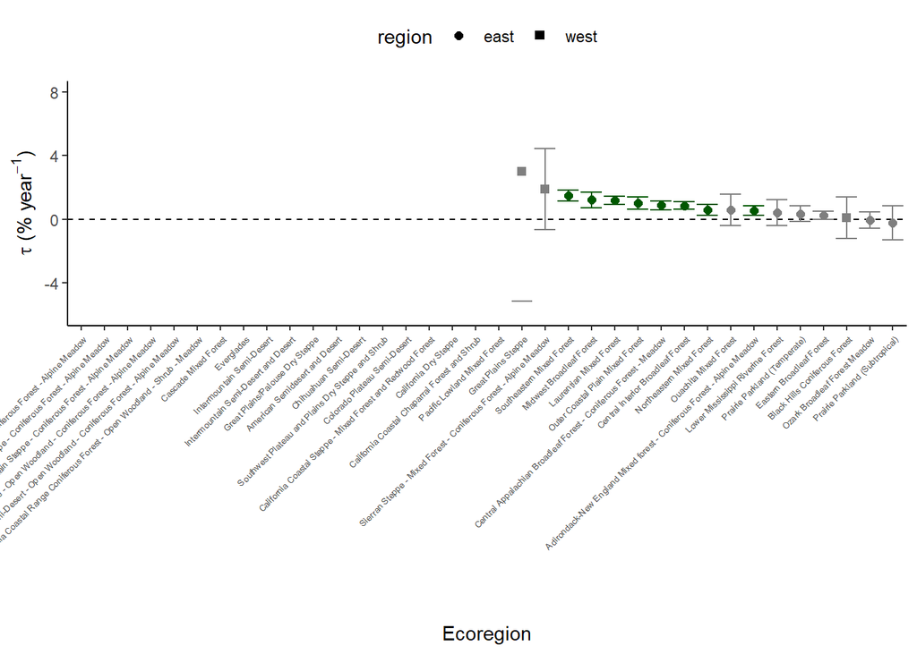

#### map

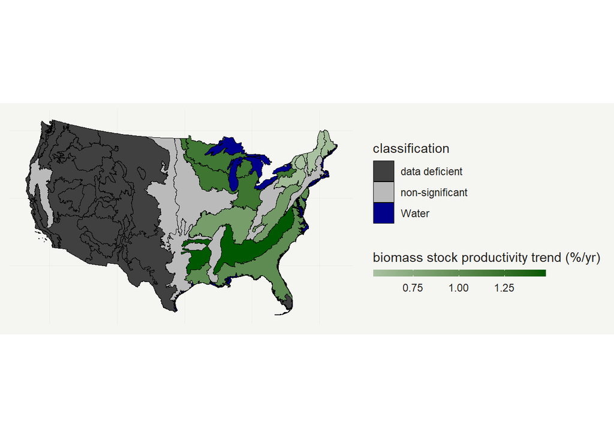

### plot alpha (biomass compensation effect)

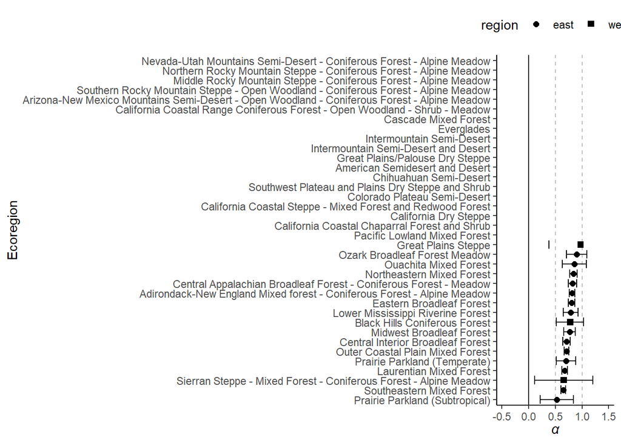

## Model Bookeeping

The model bookeeping code begins here. See the methods of the main paper for specific details, but briefly, biomass change attribution to a given driver. either: 1. changes in stand age, 2: productivity trends (as a function of measurement year), or 3: disturbance (quantified as the change in the plot fractional Biomass loss) are calculated by taking the difference between the last and first FIA plot re-measurement in the temporally-balanced dataset. For the Biomass Change (DeltaB) component in question, we use predict on the nls model varying only the given driver between the last and first re-measurement and setting the other drivers to value at the first re-measurement.

For errors in the various biomass change components, we account for model parameter uncertainty. We simulate 9999 parameter draws from the multivariate normal distribution of the nls model parameter space and predict the age function (f(x)) only using model estimates of alpha and tau in the same manner as described above.

Additional code for bookeeping model validation and plots for the supplemental information of the manuscript is contained below.

### 1. Set up Dataframes & Calculate Empirical Delta-B total

### 2. Delta-B due to Delta-STDAGE

#### simulate f(age) - Variance in DeltaB_age – rmvnorm

### 3. Delta-B due to productivity trend

#### simulate f(year) - Variance in DeltaB_productivity trend – rmvnorm

### 4. Delta-B due to disturbance

#### simulate f(disturbance) - Variance in DeltaB_disturbance – rmvnorm

#### plotting loss rate - first & last

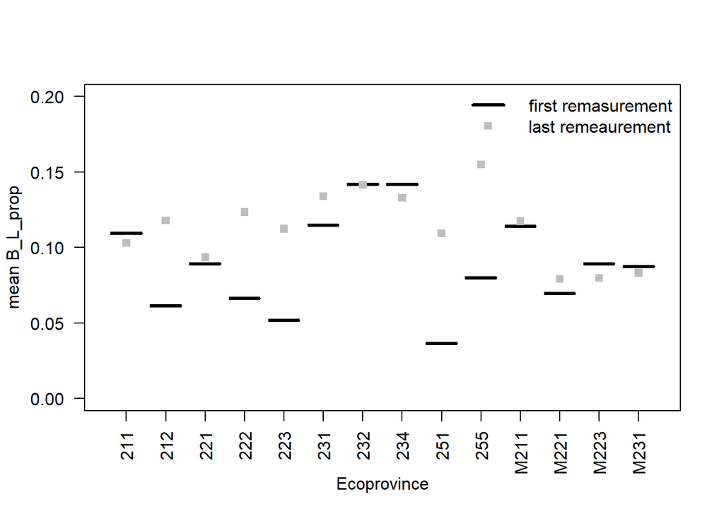

### BK_df (Bookeeping Dataframe)

#### BK_df avgs (Bookeeping averages by Ecoprovince)

### Comparing & Checking Delta_B Model Bookeeping

#### compare DeltaB_oberved and DeltaB_SUM_total

#### Delta B age vs. Delta Stand age

#### Delta B_productivity trend vs. tau

#### Delta B_disturbance vs. -alpha X MBL

### plotting Delta B

#### bookeping fig take 1

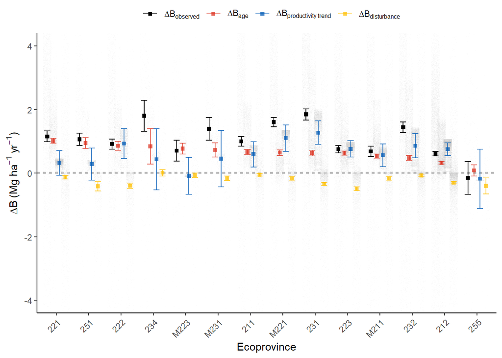

#### bookeeping fig - take 2

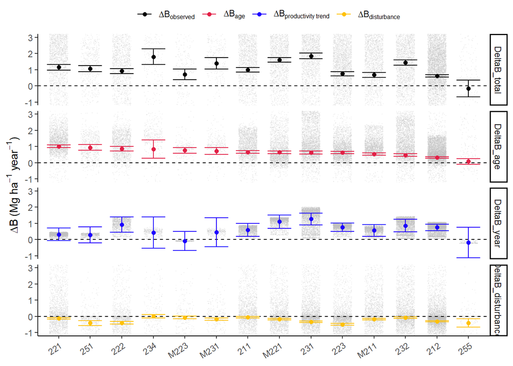

### 6. stand age densities

#### make a fig

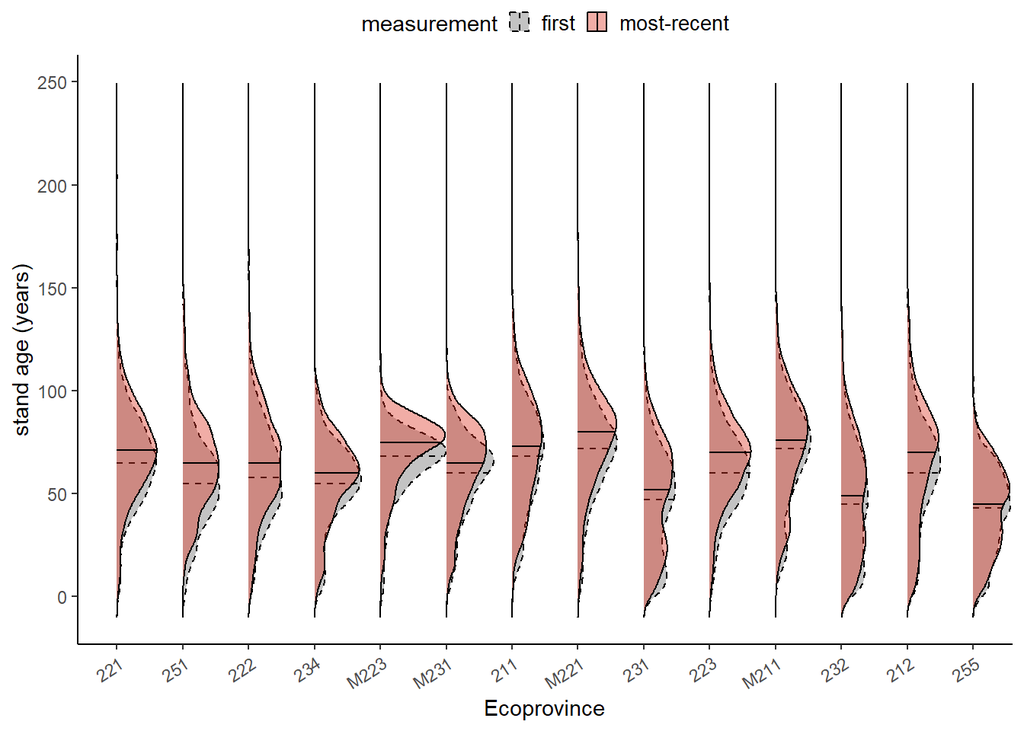

#### Fig. 3 – combined bookeeper with stand age densities

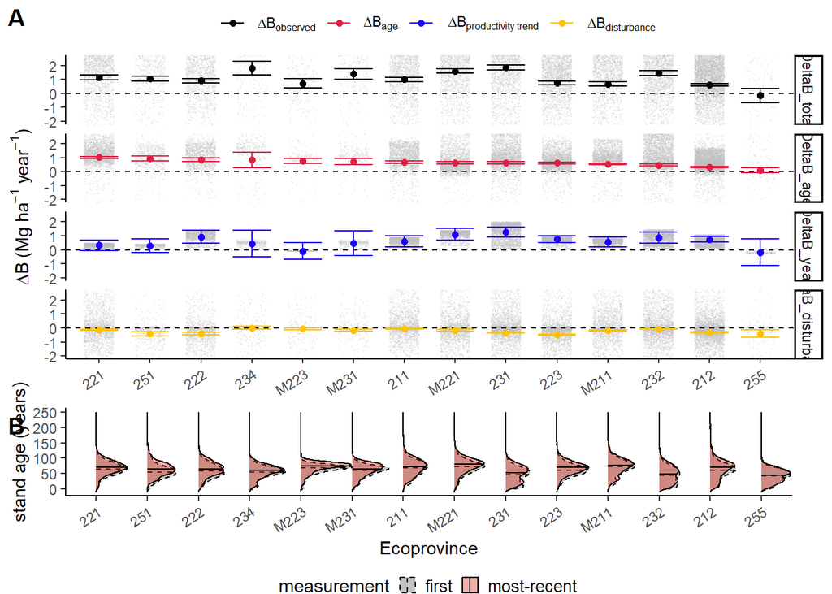

### relationship of DeltaB_observed and DeltaB_productivity trend

```
##
##  Pearson's product-moment correlation
##
## data:  BK_df$DeltaB_year and BK_df$DeltaB_total
## t = -16.291, df = 31577, p-value < 2.2e-16
## alternative hypothesis: true correlation is not equal to 0
## 95 percent confidence interval:
##  -0.10222372 -0.08034876
## sample estimates:
##         cor
## -0.09129725
```

```
##
##  Pearson's product-moment correlation
##
## data:  year_avg_merger1$value_year and year_avg_merger1$value_total
## t = 2.6013, df = 12, p-value = 0.02317
## alternative hypothesis: true correlation is not equal to 0
## 95 percent confidence interval:
##  0.1025738 0.8577687
## sample estimates:
##       cor
## 0.6004734
```

### relationship of DeltaB_observed and DeltaB_age

```
##
##  Pearson's product-moment correlation
##
## data:  BK_df$DeltaB_age and BK_df$DeltaB_total
## t = 116.95, df = 31577, p-value < 2.2e-16
## alternative hypothesis: true correlation is not equal to 0
## 95 percent confidence interval:
##  0.5420054 0.5573981
## sample estimates:
##       cor
## 0.5497484
```

```
##
##  Pearson's product-moment correlation
##
## data:  year_avg_merger2$value_age and year_avg_merger2$value_total
## t = 2.1683, df = 12, p-value = 0.05095
## alternative hypothesis: true correlation is not equal to 0
## 95 percent confidence interval:
##  -1.667272e-05  8.280454e-01
## sample estimates:
##       cor
## 0.5305675
```

### relationship of DeltaB_observed and DeltaB_disturbance

```
##
##  Pearson's product-moment correlation
##
## data:  BK_df$DeltaB_disturbance and BK_df$DeltaB_total
## t = 138.31, df = 31577, p-value < 2.2e-16
## alternative hypothesis: true correlation is not equal to 0
## 95 percent confidence interval:
##  0.6072941 0.6210318
## sample estimates:
##       cor
## 0.6142095
```

```
##
##  Pearson's product-moment correlation
##
## data:  year_avg_merger3$value_disturbance and year_avg_merger3$value_total
## t = 1.5951, df = 12, p-value = 0.1367
## alternative hypothesis: true correlation is not equal to 0
## 95 percent confidence interval:
##  -0.1443603  0.7765129
## sample estimates:
##       cor
## 0.4182553
```

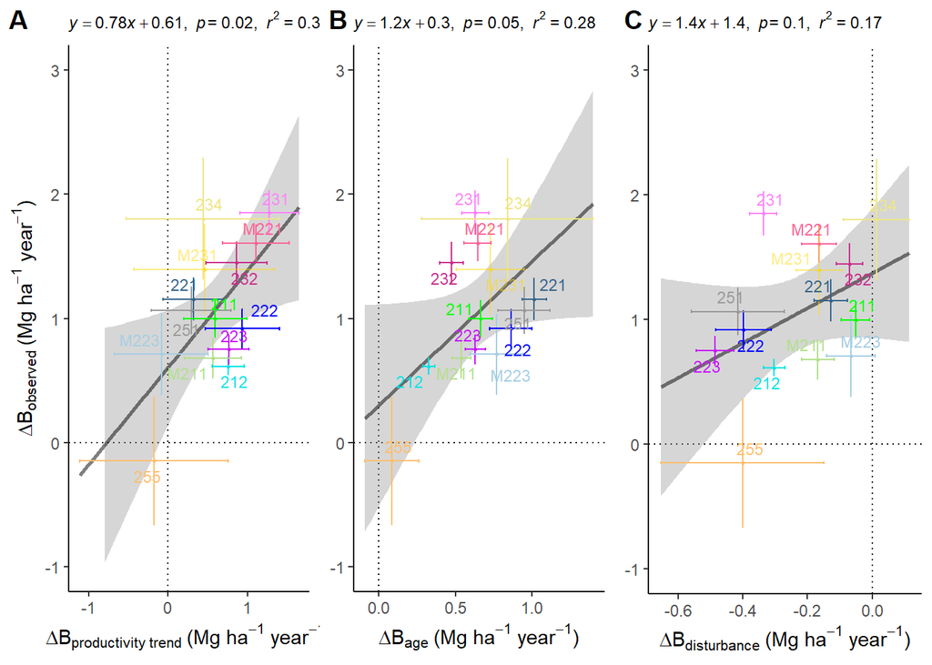

### plotting compare Delta B altogether

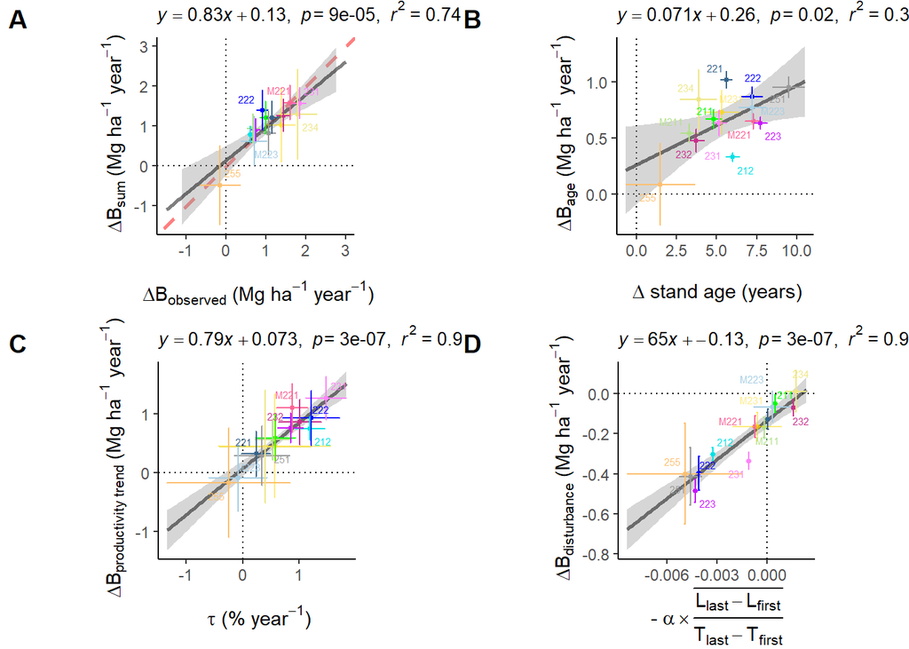